# CO2SYS_HW

Jose Martinez

2023-04-10

# Introduction

CO2SYS is a tool used mainly by carbonate chemists to calculate all of the carbonate chemistry parameters from just two of the main parameters (pH,pCo2,TA,DIC) and temperature, salinity,pressure (bars) and for more detail the amount phosphate and silicate. There exists many forms of the CO2SYS set of equations on excel, R, and other coding languages but for the purposes of this assignment we used carb function found under the seacarb library. This specific CO2SYS with just two main carbonate chemistry parameters (in our case DIC and TA) and a few other basic parameters can calculate for us T,Patm,P,pH,CO2 (mol/kg), pCO2 (μatm), fCO2 (μatm), pCO2pot (μatm) (i.e potential), fCO2pot (μatm), pCO2insitu (μatm),fCO2insitu (μatm), HCO3 (mol/kg), CO3(mol/kg),DIC (mol/kg),ALK (mol/kg), OmegaAragonite (saturation state with respect to aragonite),OmegaCalcite (saturation state with respect to Calcite).

The data used here is from the BATS site in the North Atlantic Ocean which has taken continous oceanographic data from 1988 to present. The parameters continuously recorded are shown and explained below. This small project involves taking the data from this station and running it through CO2SYS in R to possibly answer the following questions.

## Can we quantify ocean acidification in the subtropical North Atlantic Ocean?

1. Is surface ocean pCo2 increasing?
2. is surface ocean seawater pH decreasing?
3. Is surface ocean seawater saturation state with respect to aragonite decreasing?

# Methods:

Using Co2sys in R:

We first adjust all the parameters units measured in BATS by switching them from umol/kg to mol/kg in DIC,TA,Silicate,and Phosphate by multiplying by 10^-6. We also took depth from BATS bottle and got equivalent dbar pressure values needed by co2sys and also converted the units from dbar to bar by multiplying by 10^-1. Temperature and salinity could be used as measured and collected in the bats bottle data. We then inputted all the data once changed if needed into co2sys.By using mutate and piping we created a new dataframe with the prior data and resultant pCO2,carbonate ions,pH, and saturation state from co2sys.

## Variable Names

yyyymmdd = Year Month Day  
decy = Decimal Year  
time = Time (hhmm)  
latN = Latitude (Deg N) lonW = Longitude (Deg W) Depth = Depth (m)  
Temp = Temperature ITS-90 (C)  
CTD_S = CTD Salinity (PSS-78)  
Sal1 = Salinity-1 (PSS-78)  
Sig-th = Sigma-Theta (kg/m^3)  
O2(1) = Oxygen-1 (umol/kg)  
OxFixT = Oxygen Fix Temp (C)  
Anom1 = Oxy Anomaly-1 (umol/kg)  
CO2 = dissolved inorganic carbon (umol/kg)  
Alk = Alkalinity (uequiv)  
NO31 = Nitrate+Nitrite-1 (umol/kg) NO21 = Nitrite-1 (umol/kg)  
PO41 = Phosphate-1 (umol/kg)  
Si1 = Silicate-1 (umol/kg)  
POC = POC (ug/kg)  
PON = PON (ug/kg)  
TOC = TOC (umol/kg)  
TN = TN (umol/kg)  
Bact = Bacteria enumeration (cells*10^8/kg)  
POP = POP (umol/kg) TDP = Total dissolved Phosphorus (nmol/kg) SRP = Low-level phosphorus (nmol/kg) BSi = Particulate biogenic silica (umol/kg) LSi = Particulate lithogenic silica (umol/kg) Pro = Prochlorococcus (cells/ml) Syn = Synechococcus (cells/ml) Piceu = Picoeukaryotes (cells/ml) Naneu = Nanoeukaryotes (cells/ml)

Quality flags -999 = Missing or bad data 0 = Less than detection limit

### To be able to run the BATS data into CO2SYS we have to fix the units or convert some units like pressure which we did in the coding section above.

DIC umol/kg we need mol/kg DIC*10^-6

TA is in uequiv, which is essentially (umol/kg) we need mol/kg

Alk*10^-6

S is in PSS and we will EOS80 (PSS)

Sal1

T is in degrees C and we need degrees

Temp

Sit is in umol/kg, we need mol/kg

Si1*10^-6

Pt is in umol/kg we need mol/kg

PO41*10^-6

P_gsw is in dbar and we need bar

P_gsw*10^-1

```r
bats_co2sys =
  bats_co2 %>%
  filter(Alk!=-999,CO2!=-999,Sal1!=-999,Temp!=-999,P_gsw!=-999,PO41!=-999,Si1!=-999,lonW!=-999,latN!=-999) %>%
  rename(TotalC=CO2) %>%
  mutate(carb(flag =15, var1 = Alk*10^-6, var2 = TotalC*10^-6,
                 S= Sal1,
                 T= Temp,
                 Patm=1,
                 P=P_gsw*10^-1,
                 Pt=PO41*10^-6,
                 Sit=Si1*10^-6,
                 k1k2="l", kf="pf", ks="d", pHscale="T", b="u74", gas="potential",
                 warn="y", eos="eos80", long=360-lonW, lat=latN))

bats_co2sys_surf =
  bats_co2sys %>%
  filter(Depth < 100)
```

```r
pCO2_time = lm(pCO2insitu~decy,data =  bats_co2sys_surf) # y (Sig) is a function of x(decy), lm(y~x,data = data )

summary(pCO2_time) #pvalue same as anova
```

```
##
## Call:
## lm(formula = pCO2insitu ~ decy, data = bats_co2sys_surf)
##
## Residuals:
##     Min      1Q  Median      3Q     Max
## -316.43  -17.93   -6.94   12.86  173.45
##
## Coefficients:
##               Estimate Std. Error t value Pr(>|t|)
## (Intercept) -3.361e+03  1.379e+02  -24.38   <2e-16 ***
## decy         1.852e+00  6.866e-02   26.97   <2e-16 ***
## ---
## Signif. codes:  0 '***' 0.001 '**' 0.01 '*' 0.05 '.' 0.1 ' ' 1
##
## Residual standard error: 26.73 on 1938 degrees of freedom
## Multiple R-squared:  0.2729, Adjusted R-squared:  0.2725
## F-statistic: 727.5 on 1 and 1938 DF,  p-value: < 2.2e-16
```

```r
anova(pCO2_time) #pvalue is same as summary
```

```
## Analysis of Variance Table
##
## Response: pCO2insitu
##             Df  Sum Sq Mean Sq F value    Pr(>F)
## decy         1  519586  519586  727.47 < 2.2e-16 ***
## Residuals 1938 1384199     714
## ---
## Signif. codes:  0 '***' 0.001 '**' 0.01 '*' 0.05 '.' 0.1 ' ' 1
```

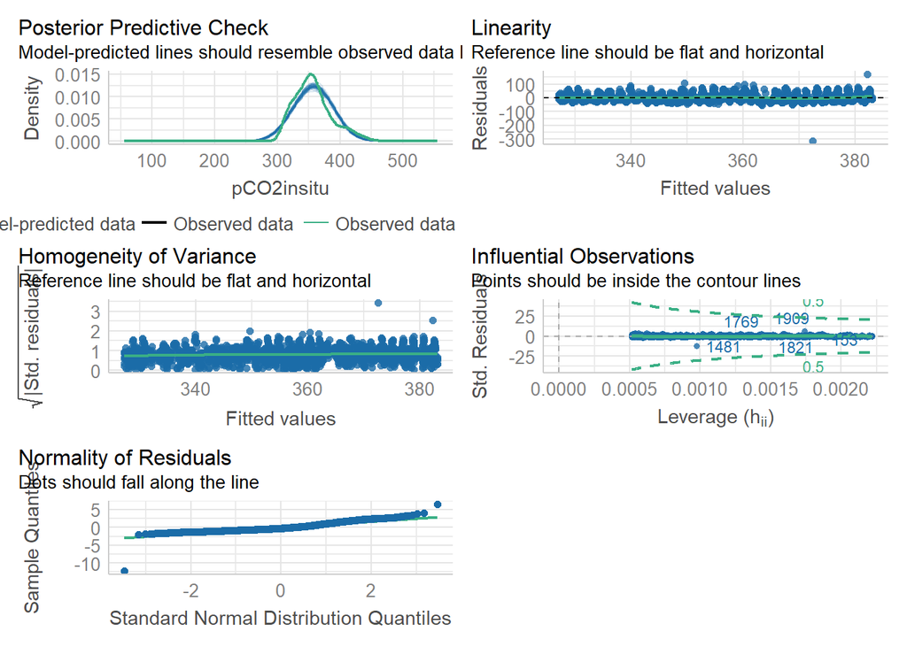

```r
check_model(pCO2_time) # Model assumptions appear valid
```

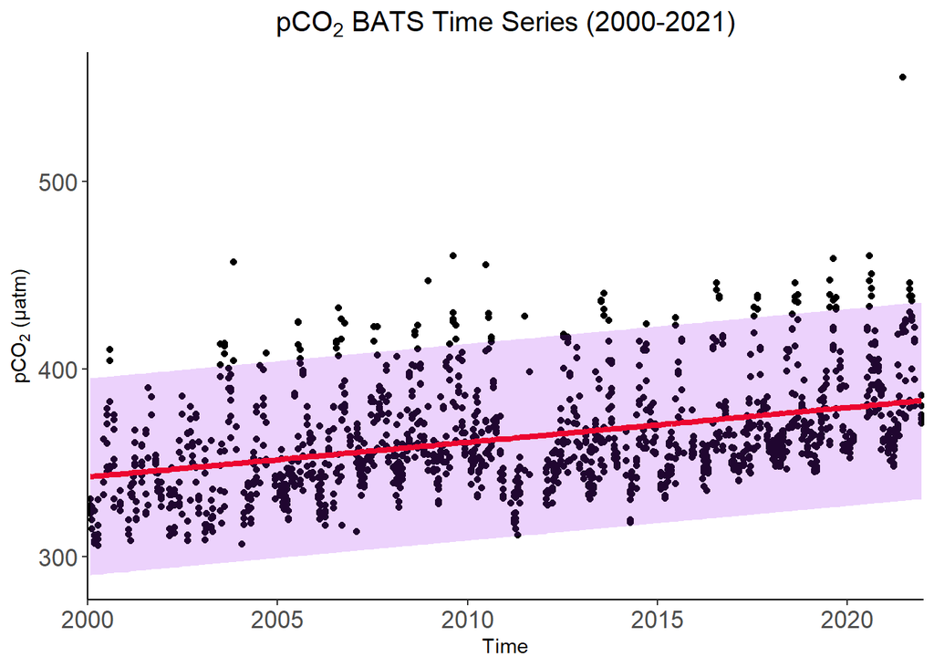

```r
bats_co2sys_surf_pred =

  bats_co2sys_surf %>%
  mutate(predict(pCO2_time, interval ='prediction', level=0.95))
# the base R way with cbind and do not need to rename outputs
bats_co2sys_surf_pred =
cbind(bats_co2sys_surf, predict(pCO2_time, interval ='prediction', level =0.95))

bats_co2sys_surf_pred %>%
  filter(decy>2000) %>%
  filter(pCO2insitu > 200) %>% # BATS told me this point was bad so I am not going to include it
  ggplot()+
  geom_point(mapping = aes(x=decy,y=pCO2insitu))+
  geom_line(aes(x=decy,y=fit),color ='red',size = 1.5)+
  geom_ribbon(aes(x=decy,ymin = lwr,ymax = upr),alpha = 0.2,fill = 'purple')+
  xlab('Time')+
  scale_x_continuous(limits = c(2000,2022), expand = c(0,0),breaks = seq(2000,2025,5))+
  labs(y=expression(pCO[2]*" (µatm)"))+
  #ggtitle('PCO2 Time Series (1988-2021)')+
  labs(title=expression(pCO[2]*' BATS Time Series (2000-2021)'))+
  theme(panel.grid.major = element_blank(),
        panel.grid.minor = element_blank(),
        panel.background = element_blank(),
        axis.line = element_line(color="black"),
        axis.text.y = element_text(size = 13),
        axis.text.x = element_text(size = 13),
        #axis.title.y = element_text(vjust = 3, size = 12),
        #axis.title.x = element_text(hjust = 0.45,vjust =-1, size = 12),
        legend.position= "none",
        plot.title = element_text(hjust = 0.5, size = 15))
```

## 1) Is surface ocean pCo2 increasing?

```r
ph_time = lm(pH~decy,data =  bats_co2sys_surf) # y (Sig) is a function of x(decy), lm(y~x,data = data )

summary(ph_time) #pvalue same as anova
```

```
##
## Call:
## lm(formula = pH ~ decy, data = bats_co2sys_surf)
##
## Residuals:
##      Min       1Q   Median       3Q      Max
## -0.14826 -0.01449  0.00819  0.01984  0.59526
##
## Coefficients:
##               Estimate Std. Error t value Pr(>|t|)
## (Intercept)  1.164e+01  1.600e-01   72.72   <2e-16 ***
## decy        -1.760e-03  7.969e-05  -22.09   <2e-16 ***
## ---
## Signif. codes:  0 '***' 0.001 '**' 0.01 '*' 0.05 '.' 0.1 ' ' 1
##
## Residual standard error: 0.03102 on 1938 degrees of freedom
## Multiple R-squared:  0.2011, Adjusted R-squared:  0.2007
## F-statistic:   488 on 1 and 1938 DF,  p-value: < 2.2e-16
```

```r
anova(ph_time) #pvalue is same as summary
```

```
## Analysis of Variance Table
##
## Response: pH
##             Df  Sum Sq Mean Sq F value    Pr(>F)
## decy         1 0.46947 0.46947  487.95 < 2.2e-16 ***
## Residuals 1938 1.86460 0.00096
## ---
## Signif. codes:  0 '***' 0.001 '**' 0.01 '*' 0.05 '.' 0.1 ' ' 1
```

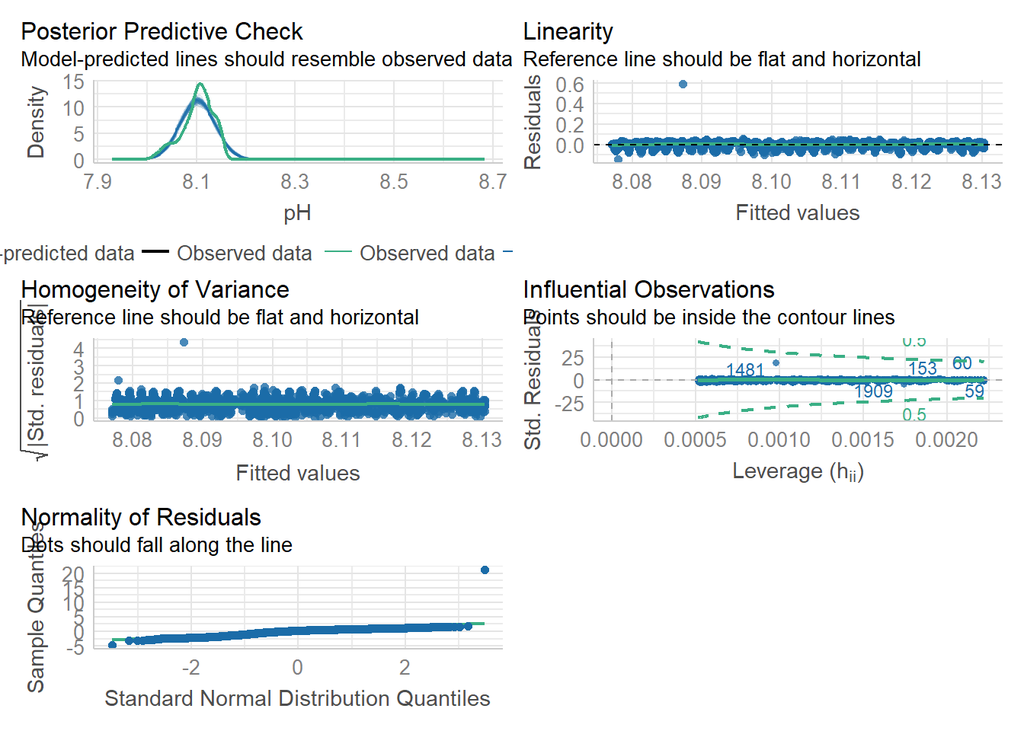

```r
check_model(ph_time) # Model assumptions appear valid
```

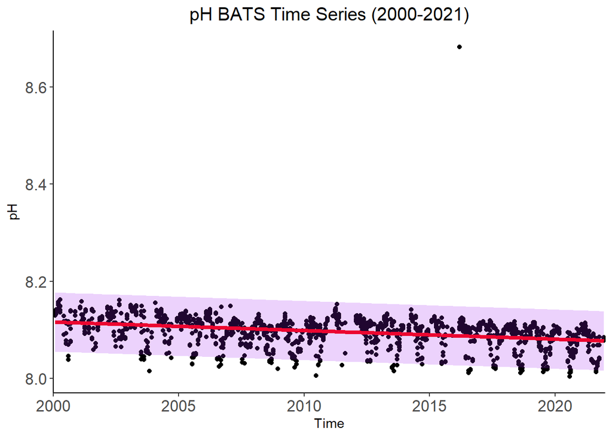

```r
bats_co2sys_surf_pred =

  bats_co2sys_surf %>%
  mutate(predict(ph_time, interval ='prediction', level=0.95))
# the base R way with cbind and do not need to rename outputs
bats_co2sys_surf_pred =
cbind(bats_co2sys_surf, predict(ph_time, interval ='prediction', level =0.95))

bats_co2sys_surf_pred %>%
  filter(decy>2000) %>%
  filter(pH>8) %>% # BATS told me this point was bad so I am not going to include it
  ggplot()+
  geom_point(mapping = aes(x=decy,y=pH))+
  geom_line(aes(x=decy,y=fit),color ='red',size = 1.5)+
  geom_ribbon(aes(x=decy,ymin = lwr,ymax = upr),alpha = 0.2,fill = 'purple')+
  xlab('Time')+
  scale_x_continuous(limits = c(2000,2022), expand = c(0,0),breaks = seq(2000,2025,5))+
  labs(y=expression(pH))+
  #ggtitle('PCO2 Time Series (1988-2021)')+
  labs(title= 'pH BATS Time Series (2000-2021)')+
  theme(panel.grid.major = element_blank(),
        panel.grid.minor = element_blank(),
        panel.background = element_blank(),
        axis.line = element_line(color="black"),
        axis.text.y = element_text(size = 13),
        axis.text.x = element_text(size = 13),
        #axis.title.y = element_text(vjust = 3, size = 12),
        #axis.title.x = element_text(hjust = 0.45,vjust =-1, size = 12),
        legend.position= "none",
        plot.title = element_text(hjust = 0.5, size = 15))
```

## 2) Is surface ocean seawater pH decreasing?

We see the seasonal cycle again with pH with higher pH corresponding to low pCO2 in the water column as less carbon dioxide in can make the water column more basic. We see higher pH in the winter corresponding with lower pCO2 in and subsequently lower pH in the summer/early fall when pCO2 increases. We do see a detectable decrease of pH of -1.760e-03 occuring annualy which corroborates with the ANOVA (p<0.001). This decrease may look small but we have to consider that pH is on the log scale.

```r
arg_time = lm(OmegaAragonite~decy,data =  bats_co2sys_surf) # y (Sig) is a function of x(decy), lm(y~x,data = data )

summary(arg_time) #pvalue same as anova
```

```
##
## Call:
## lm(formula = OmegaAragonite ~ decy, data = bats_co2sys_surf)
##
## Residuals:
##     Min      1Q  Median      3Q     Max
## -1.1226 -0.1362 -0.0183  0.1333  4.4593
##
## Coefficients:
##               Estimate Std. Error t value Pr(>|t|)
## (Intercept) 14.8305321  1.1109973   13.35   <2e-16 ***
## decy        -0.0055852  0.0005533  -10.09   <2e-16 ***
## ---
## Signif. codes:  0 '***' 0.001 '**' 0.01 '*' 0.05 '.' 0.1 ' ' 1
##
## Residual standard error: 0.2154 on 1938 degrees of freedom
## Multiple R-squared:  0.04995,    Adjusted R-squared:  0.04946
## F-statistic: 101.9 on 1 and 1938 DF,  p-value: < 2.2e-16
```

```r
anova(arg_time) #pvalue is same as summary
```

```
## Analysis of Variance Table
##
## Response: OmegaAragonite
##             Df Sum Sq Mean Sq F value    Pr(>F)
## decy         1  4.726  4.7257  101.89 < 2.2e-16 ***
## Residuals 1938 89.889  0.0464
## ---
## Signif. codes:  0 '***' 0.001 '**' 0.01 '*' 0.05 '.' 0.1 ' ' 1
```

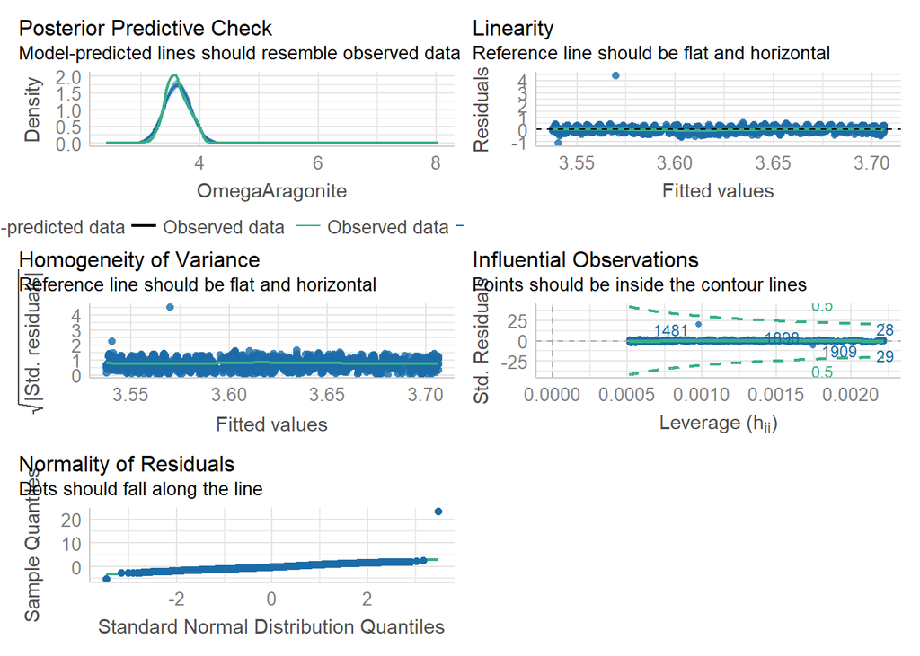

```r
check_model(arg_time) # Model assumptions appear valid
```

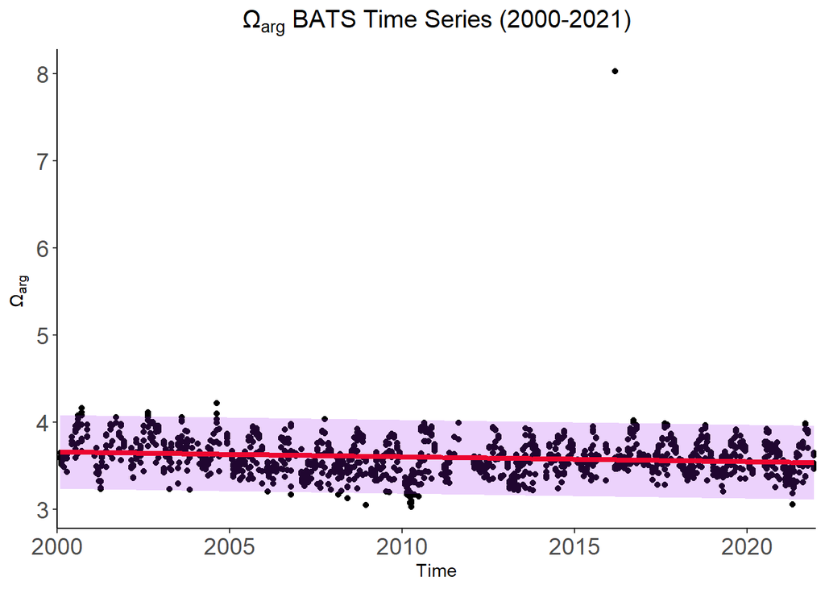

```r
bats_co2sys_surf_pred =

  bats_co2sys_surf %>%
  mutate(predict(arg_time, interval ='prediction', level=0.95))
# the base R way with cbind and do not need to rename outputs
bats_co2sys_surf_pred =
cbind(bats_co2sys_surf, predict(arg_time, interval ='prediction', level =0.95))

bats_co2sys_surf_pred %>%
  filter(decy>2000) %>%
  filter(OmegaAragonite>2.5) %>% # BATS told me this point was bad so I am not going to include it
  ggplot()+
  geom_point(mapping = aes(x=decy,y=OmegaAragonite))+
  geom_line(aes(x=decy,y=fit),color ='red',size = 1.5)+
  geom_ribbon(aes(x=decy,ymin = lwr,ymax = upr),alpha = 0.2,fill = 'purple')+
  xlab('Time')+
  scale_x_continuous(limits = c(2000,2022), expand = c(0,0),breaks = seq(2000,2025,5))+
  labs(y=expression(Ω[arg]*" "))+
  #ggtitle('PCO2 Time Series (1988-2021)')+
  labs(title= expression(Ω[arg]* ' BATS Time Series (2000-2021)'))+
  theme(panel.grid.major = element_blank(),
        panel.grid.minor = element_blank(),
        panel.background = element_blank(),
        axis.line = element_line(color="black"),
        axis.text.y = element_text(size = 14),
        axis.text.x = element_text(size = 14),
        #axis.title.y = element_text(vjust = 3, size = 12),
        #axis.title.x = element_text(hjust = 0.45,vjust =-1, size = 12),
        legend.position= "none",
        plot.title = element_text(hjust = 0.5, size = 15))
```

## 3) Is surface ocean seawater saturation state with respect to aragonite decreasing?

Saturation state also has a seasonal cycle similar to pH and pCO2. Most likely the seasonality is a result of the changing carbon dioxide concentration or the change in pH or more than likely a combination of both and other parameters like DIC and TA resulting in saturation state to change with the seasons. We see a detectable decrease of saturation state of -0.0055852 per year and the ANOVA tells us this its consistent by reporting a p-value less than 0.001.